# Final Project Executive Summary

# Finding the Best Model

Two recipes were developed to account for simple regression models as well as more complex models that require tuning.

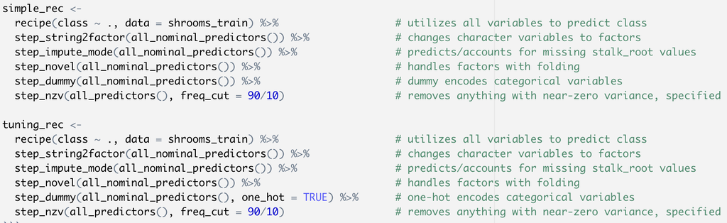

The model specification, workflow, parameter grid, and resample fitting were completed for a null model, logistic regression model, random forest model, boosted tree model, and k-nearest neighbors model. These models were then compared to see which ones provided the most accuracy.

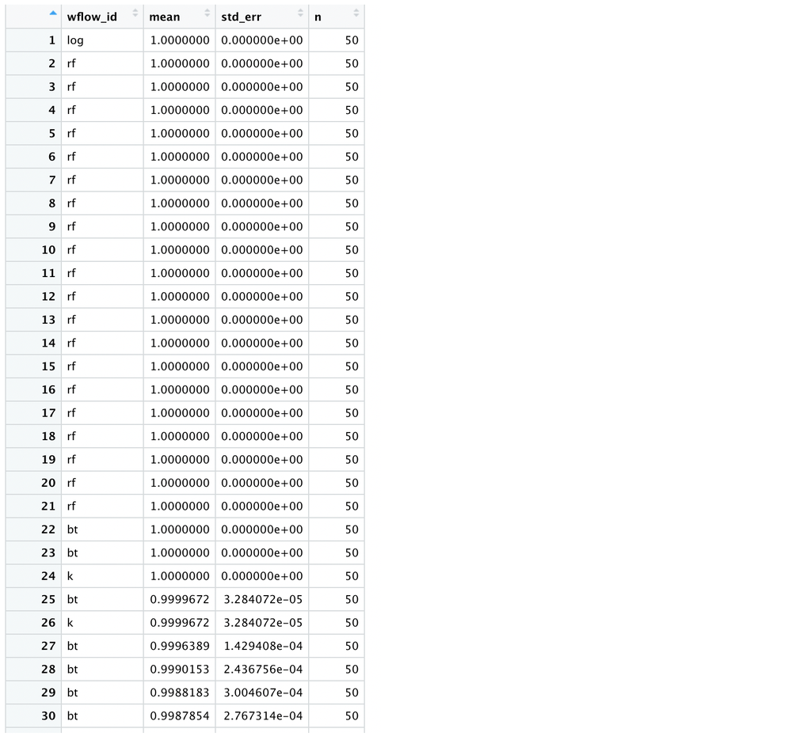

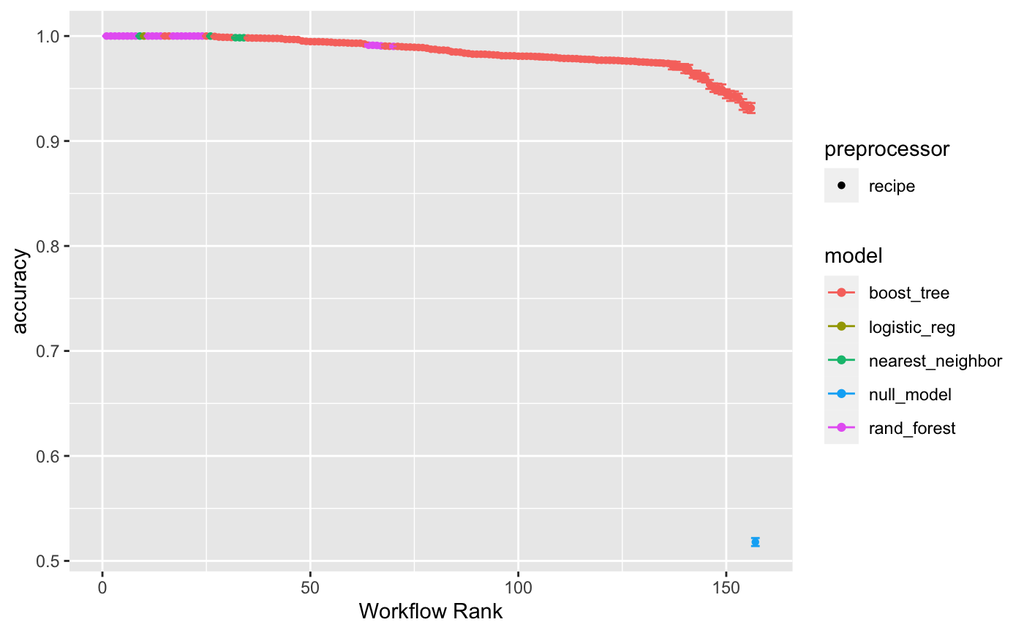

# Debrief & Next Steps

However, I think it would be interesting to conduct variable of importance tests on each model to see if the models have 100% accuracy in their predictions by taking the same or different approach. In other words, this would enable us to see if there are various different combinations of predictor variables that may underlie edible or poisonous mushrooms. While the logistic regression model seems the simplest, this would underscore the approach each model takes and thus allows for a better model selection process to be underway.